# Statistical Rethinking (Code)

Chapter 7

March, 2017

## National Economies

#### R Code 7.1

Naming a data frame after one of its variables is not a very good idea. Let’s rename the data and

- add in log of 2000 GDP,
- add `continent`, which is handy for plotting later
- remove countries that don’t have 2000 GDP data (since they won’t be used in the analysis below)

```r
library(rethinking)
data(rugged)

Nations <-
  rugged %>%
  mutate(
    log_gdp = log(rgdppc_2000),
    continent = ifelse(cont_africa, "Africa", "Other")
  ) %>%
  filter(! is.na(log_gdp))

dim(Nations)
```

```
## [1] 170  53
```

```r
dim(rugged)
```

```
## [1] 234  51
```

Here we partition the data into African and non-African nations.

```r
# split countries into Africa and not-Africa
Nations_A1 <- Nations %>% filter(cont_africa == 1)
Nations_A0 <- Nations %>% filter(cont_africa == 0)
sapply(list(All = Nations, Africa = Nations_A1, Other = Nations_A0), nrow)
```

```
##    All Africa  Other
##    170     49    121
```

#### Scatter plot

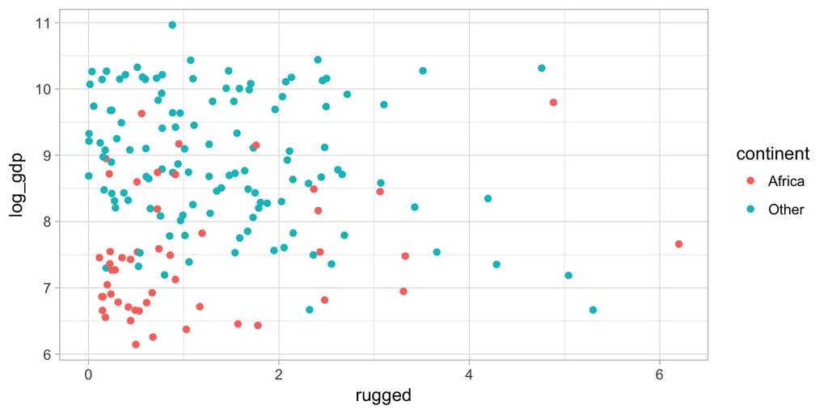

```r
gf_point(log_gdp ~ rugged + color::continent, data = Nations)
```

#### R Code 7.2

Here’s a bad idea (because there are better ideas): We could fit models on the African and non-African countries separately.

```r
# African nations
m7.1 <-
  map(
    alist(
      log_gdp ~ dnorm(mu, sigma),
      mu <- a + bR * rugged,
      a ~ dnorm(8, 100),
      bR ~ dnorm(0, 1),
      sigma ~ dunif(0, 10)
    ),
    data = Nations_A1)

# non-African nations
m7.2 <-
  map(
    alist(
      log_gdp ~ dnorm(mu, sigma),
      mu <- a + bR * rugged,
      a ~ dnorm(8, 100),
      bR ~ dnorm(0, 1),
      sigma ~ dunif(0, 10)
    ),
    data = Nations_A0)
```

#### R Code 7.3

This models the association between GDP and ruggedness (using all the nations).

```r
m7.3 <-
  map(
    alist(
      log_gdp ~ dnorm(mu, sigma),
      mu <- a + bR * rugged,
      a ~ dnorm(8, 100),
      bR ~ dnorm(0, 1),
      sigma ~ dunif(0, 10)
    ),
    data = Nations)
```

#### R Code 7.4

This model includes an additional predictor: whether or not the country is in Africa).

```r
m7.4 <- map(
  alist(
    log_gdp ~ dnorm(mu, sigma),
    mu <- a + bR * rugged + bA * cont_africa,
    a ~ dnorm(8, 100),
    bR ~ dnorm(0, 1),
    bA ~ dnorm(0, 1),
    sigma ~ dunif(0, 10)
  ),
  data = Nations
)
```

#### R Code 7.5

```r
compare(m7.3, m7.4)
```

```
##       WAIC pWAIC dWAIC weight    SE   dSE
## m7.4 476.3   4.4   0.0      1 15.36    NA
## m7.3 539.8   2.8  63.5      0 13.31 15.14
```

#### R Code 7.6

This is quite different in approach to the code from the book.  
Instead of creating two separate data sets, we can do this all at once, using `expand.grid()` to create a sequence of `rugged` values for both in and out of Africa.

Advantages:

- less code
- more clarity
- less chance to accidentally do different things on the two halves
- plotting is easier because the results are all in one place

At let’s use better names for things as well. In particular, we’ll name the data frame that is collecting predictions after the thing being predicted. (We don’t want to name it after the model, because we will be comparing different models’ predictions.)

```r
Loggdp_predict <-
  expand.grid(
    cont_africa = 0:1,
    rugged = seq(from = 0, to = 8, by = 0.2)
  ) %>%
  mutate(
    continent = ifelse(cont_africa, "Africa", "Other")
  )
m7.4_link <- link(m7.4, data = Loggdp_predict, refresh = 0)

# add in means and intervals using m7.4
Loggdp_predict <-
  Loggdp_predict %>%
  mutate(
    m7.4.mu = apply(m7.4_link, 2, mean),
    m7.4.lo = apply(m7.4_link, 2, PI, prob = 0.97)[1,],
    m7.4.hi = apply(m7.4_link, 2, PI, prob = 0.97)[2,]
  )
```

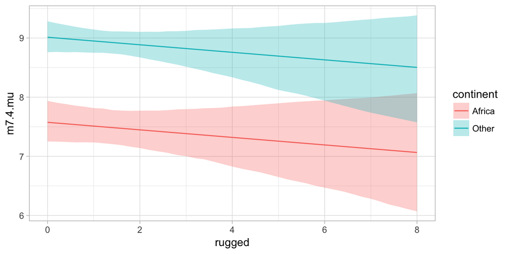

```r
gf_line(m7.4.mu ~ rugged + color:continent,
        data = Loggdp_predict) %>%
gf_ribbon(m7.4.lo + m7.4.hi ~ rugged + fill:continent,
        data = Loggdp_predict)
```

With the original data overlaid

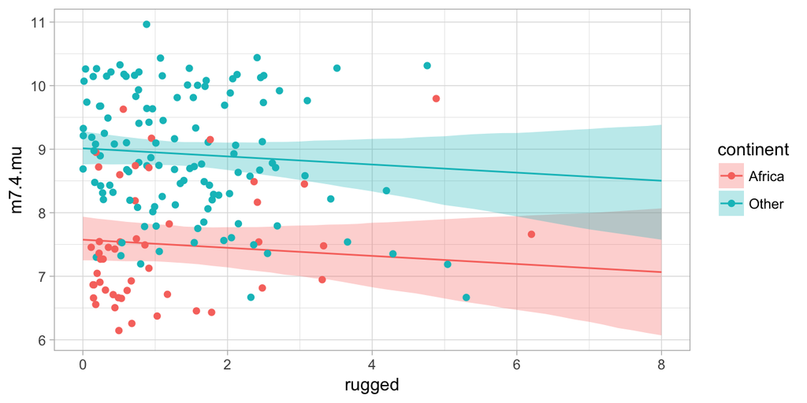

```r
last_plot() %>%
  gf_point(log_gdp ~ rugged + color:continent, data = Nations)
```

A squre root transformation on the x-axis helps to spread out the cluster of dots near 0.

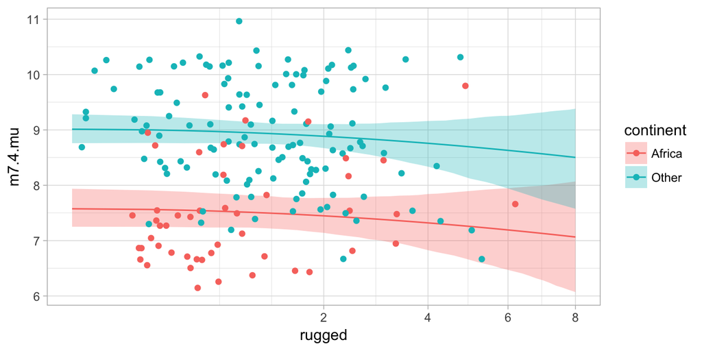

```r
last_plot() %>%
  gf_refine(scale_x_continuous(trans = "sqrt"))
```

Residuals

```r
# computing residuals is expensive, so let's save them
m7.4.resid <- resid(m7.4)
```

```
## Residuals computed assuming outcome = log_gdp
```

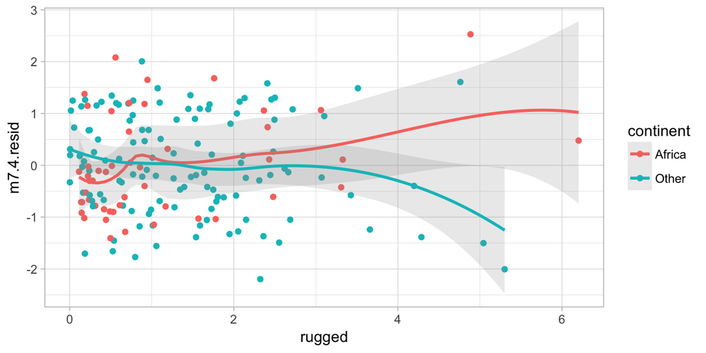

```r
gf_point(m7.4.resid ~ rugged + color:continent, data = Nations) %>%
  gf_smooth(m7.4.resid ~ rugged + color:continent, data = Nations, alpha = 0.2)
```

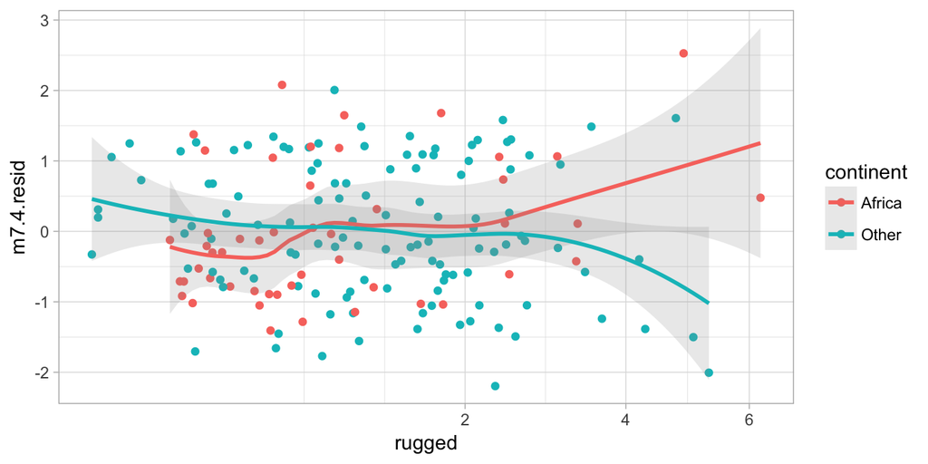

```r
last_plot() %>%
  gf_refine(scale_x_continuous(trans = "sqrt"))
```

This reveals several things:

- there is quite a bit of scatter. Countries in the same continent, with teh same amount of ruggedness may have quite different GDP.
- African and non-African countries appear to be different, but most of the difference is coming from the most rugged countries, and there aren’t very many of those.

#### R Code 7.7

A model with “interaction”.

```r
m7.5 <-
  map(
    alist(
      log_gdp ~ dnorm(mu, sigma),
      mu <- a + gamma * rugged + bA * cont_africa,
      gamma <- bR + bAR * cont_africa,
      a ~ dnorm(8, 100),
      bA ~ dnorm(0, 1),
      bR ~ dnorm(0, 1),
      bAR ~ dnorm(0, 1),
      sigma ~ dunif(0, 10)
    ),
    data = Nations
  )
```

#### R Code 7.8

```r
compare(m7.3, m7.4, m7.5)
```

```
##       WAIC pWAIC dWAIC weight    SE   dSE
## m7.5 469.3   5.1   0.0   0.97 15.06    NA
## m7.4 476.0   4.2   6.8   0.03 15.25  6.10
## m7.3 539.7   2.7  70.4   0.00 13.21 15.08
```

#### R Code 7.9

Alternative coding for `m7.5b`.

```r
m7.5b <-
  map(
    alist(
      log_gdp ~ dnorm(mu, sigma),
      mu <- a + bR * rugged + bAR * rugged * cont_africa + bA * cont_africa,
      a ~ dnorm(8, 100),
      bA ~ dnorm(0, 1),
      bR ~ dnorm(0, 1),
      bAR ~ dnorm(0, 1),
      sigma ~ dunif(0, 10)
    ),
    data = Nations
  )
```

#### R Code 7.10

We can add the predictions from the new model to our existing `Loggdp_predict` data frame since we want the same rows – just additional columns.

```r
m7.5_link <- link(m7.5, data = Loggdp_predict, refresh = 0)

# add in means and intervals
Loggdp_predict <-
  Loggdp_predict %>%
  mutate(
    m7.5.mu = apply(m7.5_link, 2, mean),
    m7.5.lo = apply(m7.5_link, 2, PI, prob = 0.97)[1,],
    m7.5.hi = apply(m7.5_link, 2, PI, prob = 0.97)[2,]
  )
```

This model looks quite different.

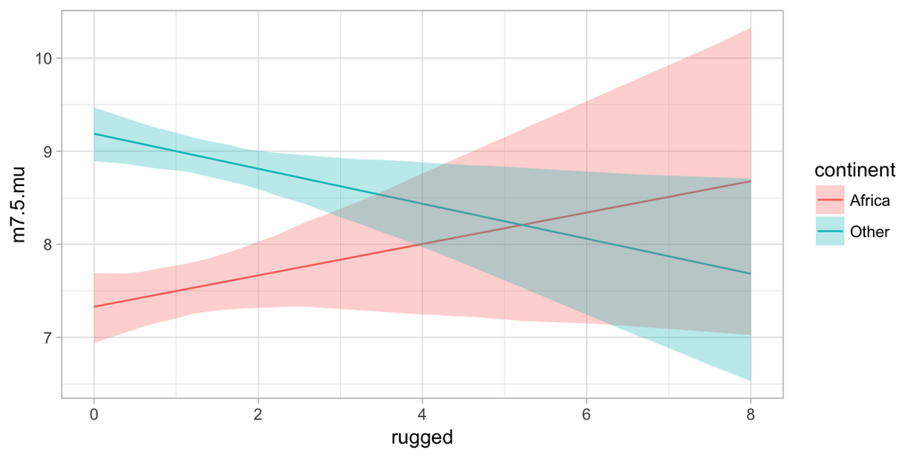

```r
gf_line(m7.5.mu ~ rugged + color:continent,
        data = Loggdp_predict) %>%
gf_ribbon(m7.5.lo + m7.5.hi ~ rugged + fill:continent,
        data = Loggdp_predict)
```

#### R Code 7.11

Now let’s compare the model to the data used to fit it.

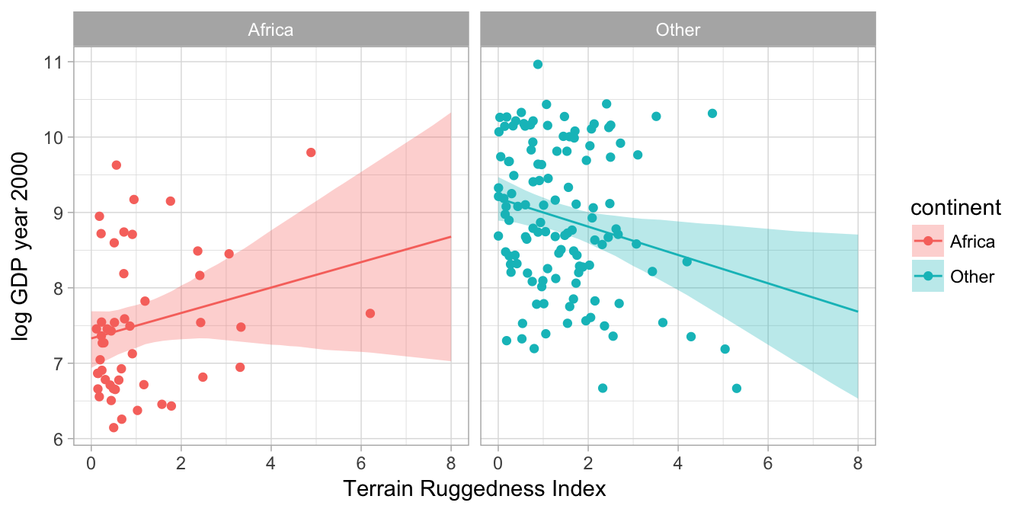

```r
# plot African nations with regression
gf_point(log_gdp ~ rugged + color:continent,
         data = Nations) %>%
  gf_line(m7.5.mu ~ rugged + col:continent, data = Loggdp_predict) %>%
  gf_ribbon(m7.5.lo + m7.5.hi ~ rugged + fill:continent,
            data = Loggdp_predict) %>%
  gf_labs(y = "log GDP year 2000", x = "Terrain Ruggedness Index")  %>%
  gf_facet_grid(~ continent)
```

#### R Code 7.12

```r
precis(m7.5)
```

```
##        Mean StdDev  5.5% 94.5%
## a      9.18   0.14  8.97  9.40
## bA    -1.85   0.22 -2.20 -1.50
## bR    -0.18   0.08 -0.31 -0.06
## bAR    0.35   0.13  0.14  0.55
## sigma  0.93   0.05  0.85  1.01
```

#### R Code 7.13

We can compute $\gamma_i$ for each posterior sample; $\gamma_i$ only depends on whether a country is in Africa or not.

```r
m7.5_post <- extract.samples(m7.5) %>%
  mutate(
    gamma.Africa = bR + bAR * 1,
    gamma.notAfrica = bR + bAR * 0
  )
```

#### R Code 7.14

Means of posterior $\gamma_i$ values.

```r
mean(m7.5_post$gamma.Africa)
```

```
## [1] 0.1628399
```

```r
mean(m7.5_post$gamma.notAfrica)
```

```
## [1] -0.1827452
```

#### R Code 7.15

Posterior distributions of $\gamma_i$’s.

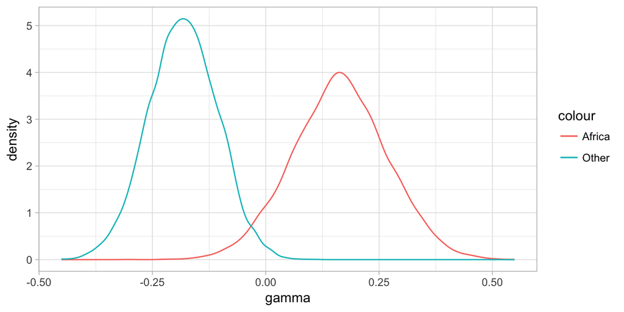

```r
gf_dens(~gamma.Africa + color::"Africa", data = m7.5_post) %>%
  gf_dens(~gamma.notAfrica + color::"Other", data = m7.5_post) %>%
  gf_labs(x = "gamma")
```

#### R Code 7.16

Posterior distribution of the difference between the two $\gamma_i$ values.

```r
gf_dens( ~ (gamma.Africa - gamma.notAfrica), data = m7.5_post)
prop( ~(gamma.Africa < gamma.notAfrica), data = m7.5_post)
```

```
##   TRUE
## 0.0036
```

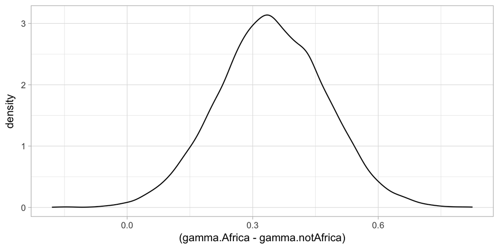

#### R Code 7.17

Here’s the original code from the book.

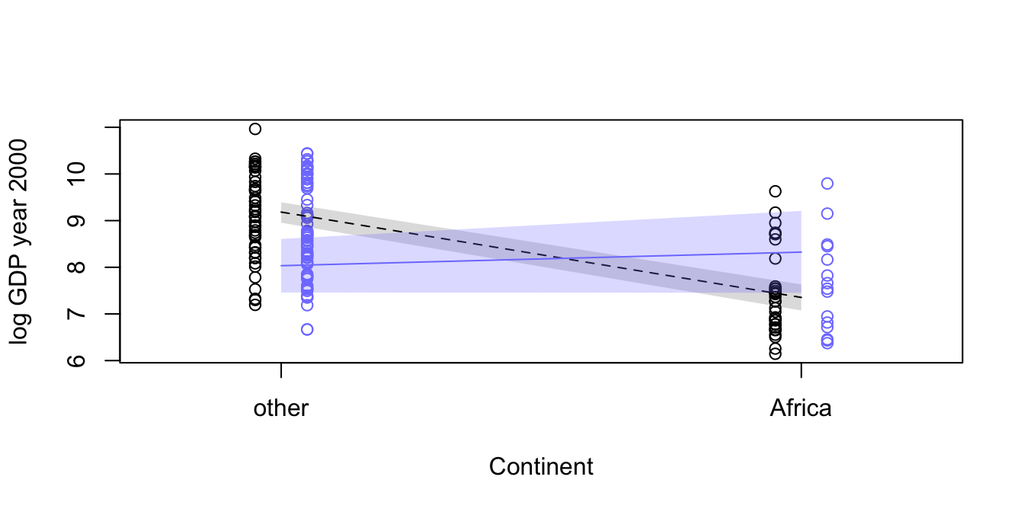

```r
# get minimum and maximum rugged values
q.rugged <- range(Nations$rugged)

# compute lines and confidence intervals
mu.ruggedlo <-
  link(m7.5, data = data.frame(rugged = q.rugged[1],
                               cont_africa = 0:1),
       refresh = 0)
mu.ruggedlo.mean <- apply(mu.ruggedlo, 2, mean)
mu.ruggedlo.PI <- apply(mu.ruggedlo, 2, PI)

mu.ruggedhi <-
  link(m7.5,
       data = data.frame(rugged = q.rugged[2],
                         cont_africa = 0:1),
       refresh = 0)
mu.ruggedhi.mean <- apply(mu.ruggedhi, 2, mean)
mu.ruggedhi.PI <- apply(mu.ruggedhi, 2, PI)

# plot it all, splitting points at median
med.r <- median(Nations$rugged)
ox <- ifelse(Nations$rugged > med.r, 0.05,-0.05)
plot(
  Nations$cont_africa + ox,
  log(Nations$rgdppc_2000),
  col = ifelse(Nations$rugged > med.r, rangi2, "black"),
  xlim = c(-0.25, 1.25),
  xaxt = "n",
  ylab = "log GDP year 2000",
  xlab = "Continent"
)
axis(1, at = c(0, 1), labels = c("other", "Africa"))
lines(0:1, mu.ruggedlo.mean, lty = 2)
shade(mu.ruggedlo.PI, 0:1)
lines(0:1, mu.ruggedhi.mean, col = rangi2)
shade(mu.ruggedhi.PI, 0:1, col = col.alpha(rangi2, 0.25))
```

We can simplify this a bit.

- We don’t need to run `link()` again – we’ve already run it.

  We don’t have the exact min and max of `rugged` in our `Loggpd_predict` data, but it’s close. (And we could use a finer mesh if we wanted to.)
- By putting a `rugged_group` variable in both data sets, we can easily color/fill/group basd on that value
- By using `position_dodge()` and our `continent` variable, we can create then entire plot using just three layers. (But notice the use of the `group` aesthetic to override the default grouping that would have happened.)
  - one for the dots (dodged left and right by rugged group)
  - one for the prediction lines
  - one for the prediction ribbons

```r
mrugged <- median(~rugged, data = Nations); mrugged
```

```
## [1] 0.9795
```

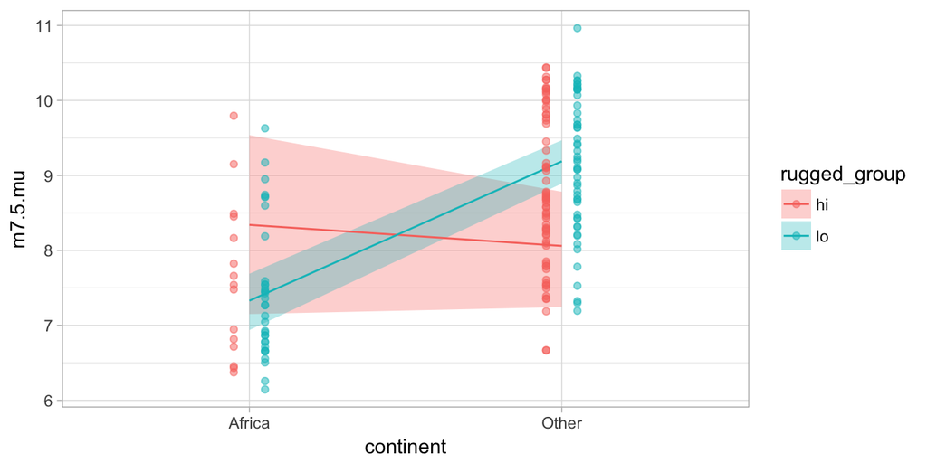

```r
Nations <-
  Nations %>%
  mutate(
    rugged_group = ifelse( rugged > mrugged, "hi", "lo"))
Loggdp_predict <-
  Loggdp_predict %>%
  mutate(
    rugged_group = ifelse( rugged > mrugged, "hi", "lo"))

gf_ribbon(
  m7.5.lo + m7.5.hi ~ continent + fill:rugged_group + group:rugged_group,
  data = Loggdp_predict %>% filter(rugged %in% c(0, 6))) %>%
  gf_line(m7.5.mu ~ continent + color:rugged_group + group:rugged_group,
          data = Loggdp_predict %>% filter(rugged %in% c(0, 6))) %>%
  gf_point( log_gdp ~ continent + color:rugged_group, data = Nations,
            position = position_dodge(width = 0.2), alpha = 0.5)
```

Here’s a fancier version that uses jitter and doge to minimize the issue of overlapping dots.

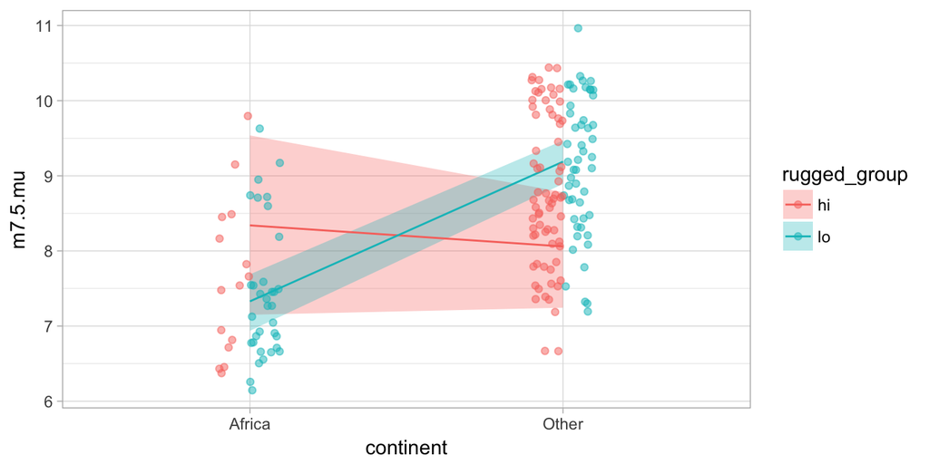

```r
gf_ribbon(
  m7.5.lo + m7.5.hi ~ continent + fill:rugged_group + group:rugged_group,
  data = Loggdp_predict %>% filter(rugged %in% c(0, 6))) %>%
  gf_line(m7.5.mu ~ continent + color:rugged_group + group:rugged_group,
          data = Loggdp_predict %>% filter(rugged %in% c(0, 6))) %>%
  gf_point( log_gdp ~ continent + color:rugged_group, data = Nations,
            position = position_jitterdodge(jitter.width = 0.1, dodge.width = 0.2),
            alpha = 0.5)
```

Note: This plot give a bit of a distorted view. The dots of each color are not all at the lowest/highest value for rugged. Using the 1st and 3rd quartiles seems fairer. That way some dots of each color will be above and some below the value of ruggedness used for the fits shown in that color.  
Another option would be to introduce new colors so that we are less inclined to draw the false conclusion.

```r
quantile(Nations$rugged)
```

```
##      0%     25%     50%     75%    100%
## 0.00300 0.44225 0.97950 1.95725 6.20200
```

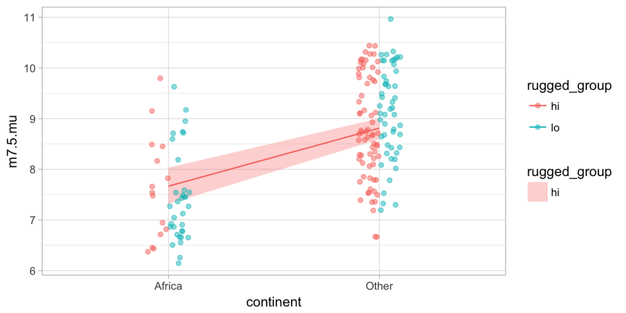

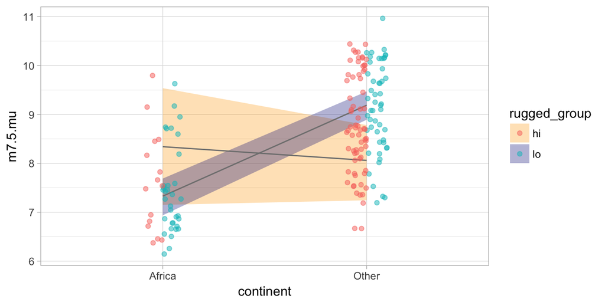

```r
gf_ribbon(
  m7.5.lo + m7.5.hi ~ continent + fill:rugged_group + group:rugged_group,
  data = Loggdp_predict %>% filter(rugged %in% c(0.5, 2))) %>%
  gf_line(m7.5.mu ~ continent + color:rugged_group + group:rugged_group,
          data = Loggdp_predict %>% filter(rugged %in% c(0.5, 2))) %>%
  gf_point( log_gdp ~ continent + color:rugged_group, data = Nations,
            position = position_jitterdodge(jitter.width = 0.1, dodge.width = 0.2),
            alpha = 0.5)
gf_ribbon(
  m7.5.lo + m7.5.hi ~ continent + fill:rugged_group + group:rugged_group,
  data = Loggdp_predict %>% filter(rugged %in% c(0, 6))) %>%
  gf_line(m7.5.mu ~ continent + color:"gray50" + group:rugged_group,
          data = Loggdp_predict %>% filter(rugged %in% c(0, 6))) %>%
  gf_point( log_gdp ~ continent + color:rugged_group, data = Nations,
            position = position_jitterdodge(jitter.width = 0.1, dodge.width = 0.2),
            alpha = 0.5) %>%
  gf_refine(
    scale_fill_manual(values = c("orange", "navy"))
  )
```

As expected, the differences don’t look as pronounced when we use the 1st and 3rd quartiles.

## Tulips

#### R Code 7.18

```r
library(rethinking)
data(tulips)
Tulips <- tulips # local version where we will add some variables later
glimpse(Tulips)
```

```
## Observations: 27
## Variables: 4
## $ bed    <fctr> a, a, a, a, a, a, a, a, a, b, b, b, b, b, b, b, b, b, ...
## $ water  <int> 1, 1, 1, 2, 2, 2, 3, 3, 3, 1, 1, 1, 2, 2, 2, 3, 3, 3, 1...
## $ shade  <int> 1, 2, 3, 1, 2, 3, 1, 2, 3, 1, 2, 3, 1, 2, 3, 1, 2, 3, 1...
## $ blooms <dbl> 0.00, 0.00, 111.04, 183.47, 59.16, 76.75, 224.97, 83.77...
```

#### R Code 7.19

```r
m7.6 <- map(
  alist(
    blooms ~ dnorm(mu, sigma),
    mu <- a + bW * water + bS * shade,
    a ~ dnorm(0, 100),
    bW ~ dnorm(0, 100),
    bS ~ dnorm(0, 100),
    sigma ~ dunif(0, 100)
  ),
  data = Tulips
)
```

```
## Error in map(alist(blooms ~ dnorm(mu, sigma), mu <- a + bW * water + bS * : non-finite finite-difference value [4]
## Start values for parameters may be too far from MAP.
## Try better priors or use explicit start values.
## If you sampled random start values, just trying again may work.
## Start values used in this attempt:
## a = 147.288355316427
## bW = 229.137580192806
## bS = 157.52049939085
## sigma = 56.8666083738208
```

```r
m7.7 <- map(
  alist(
    blooms ~ dnorm(mu, sigma),
    mu <- a + bW * water + bS * shade + bWS * water * shade,
    a ~ dnorm(0, 100),
    bW ~ dnorm(0, 100),
    bS ~ dnorm(0, 100),
    bWS ~ dnorm(0, 100),
    sigma ~ dunif(0, 100)
  ),
  data = Tulips
)
```

```
## Error in map(alist(blooms ~ dnorm(mu, sigma), mu <- a + bW * water + bS * : non-finite finite-difference value [5]
## Start values for parameters may be too far from MAP.
## Try better priors or use explicit start values.
## If you sampled random start values, just trying again may work.
## Start values used in this attempt:
## a = 64.7330949238793
## bW = -97.859321311001
## bS = -64.7183755859978
## bWS = -177.368707970701
## sigma = 52.8894809773192
```

#### R Code 7.20

```r
m7.6 <- map(
  alist(
    blooms ~ dnorm(mu, sigma),
    mu <- a + bW * water + bS * shade,
    a ~ dnorm(0, 100),
    bW ~ dnorm(0, 100),
    bS ~ dnorm(0, 100),
    sigma ~ dunif(0, 100)
  ),
  data = Tulips,
  method = "Nelder-Mead",
  control = list(maxit = 1e4)
)
m7.7 <- map(
  alist(
    blooms ~ dnorm(mu, sigma),
    mu <- a + bW * water + bS * shade + bWS * water * shade,
    a ~ dnorm(0, 100),
    bW ~ dnorm(0, 100),
    bS ~ dnorm(0, 100),
    bWS ~ dnorm(0, 100),
    sigma ~ dunif(0, 100)
  ),
  data = Tulips,
  method = "Nelder-Mead",
  control = list(maxit = 1e4)
)
```

#### R Code 7.21

```r
coeftab(m7.6, m7.7)
```

```
##       m7.6    m7.7
## a       53.60    2.62
## bW      76.31  110.85
## bS     -38.94   -4.39
## sigma   57.39   98.45
## bWS        NA  -21.34
## nobs       27      27
```

#### R Code 7.22

```r
compare(m7.6, m7.7)
```

```
## Error in mvrnorm(n = n, mu = mu, Sigma = vcov(object)): 'Sigma' is not positive definite
```

#### R Code 7.23

```r
Tulips <-
  Tulips %>%
  mutate(
    shade.c = shade - mean(shade),
    water.c = water - mean(water)
  )
```

#### R Code 7.24

```r
m7.8 <- map(
  alist(
    blooms ~ dnorm(mu, sigma),
    mu <- a + bW * water.c + bS * shade.c,
    a ~ dnorm(130, 100),
    bW ~ dnorm(0, 100),
    bS ~ dnorm(0, 100),
    sigma ~ dunif(0, 100)
  ),
  data = Tulips,
  start = list(
    a = mean(Tulips$blooms),
    bW = 0,
    bS = 0,
    sigma = sd(Tulips$blooms)
  )
)
m7.9 <- map(
  alist(
    blooms ~ dnorm(mu, sigma),
    mu <- a + bW * water.c + bS * shade.c + bWS * water.c * shade.c,
    a ~ dnorm(130, 100),
    bW ~ dnorm(0, 100),
    bS ~ dnorm(0, 100),
    bWS ~ dnorm(0, 100),
    sigma ~ dunif(0, 100)
  ),
  data = Tulips,
  start = list(
    a = mean(Tulips$blooms),
    bW = 0,
    bS = 0,
    bWS = 0,
    sigma = sd(Tulips$blooms)
  )
)
coeftab(m7.8, m7.9)
```

```
##       m7.8    m7.9
## a      129.00  129.01
## bW      74.22   74.96
## bS     -40.74  -41.14
## sigma   57.35   45.22
## bWS        NA  -51.87
## nobs       27      27
```

#### R Code 7.25

```r
k <- coef(m7.7); k
```

```
##          a         bW         bS        bWS      sigma
##   2.616795 110.851737  -4.390966 -21.344340  98.445401
```

```r
k[1] + k[2] * 2 + k[3] * 2 + k[4] * 2 * 2
```

```
##       a
## 130.161
```

```r
# here's a safer/clearer way
k["a"] + k["bW"] * 2 + k["bS"] * 2 + k["bWS"] * 2 * 2
```

```
##       a
## 130.161
```

```r
# annoyed by the name a?  (parens required here)
(k["a"] + k["bW"] * 2 + k["bS"] * 2 + k["bWS"] * 2 * 2) %>% setNames("mu.S2W2")
```

```
## mu.S2W2
## 130.161
```

#### R Code 7.26

```r
k <- coef(m7.9); k
```

```
##         a        bW        bS       bWS     sigma
## 129.00797  74.95946 -41.14054 -51.87265  45.22497
```

```r
(k["a"] + k["bW"] * 0 + k["bS"] * 0 + k["bWS"] * 0 * 0) %>% setNames("mu.S0W0")
```

```
## mu.S0W0
## 129.008
```

#### R Code 7.27

```r
precis(m7.9)
```

```
##         Mean StdDev   5.5%  94.5%
## a     129.01   8.67 115.15 142.87
## bW     74.96  10.60  58.02  91.90
## bS    -41.14  10.60 -58.08 -24.20
## bWS   -51.87  12.95 -72.57 -31.18
## sigma  45.22   6.15  35.39  55.06
```

#### R Code 7.28

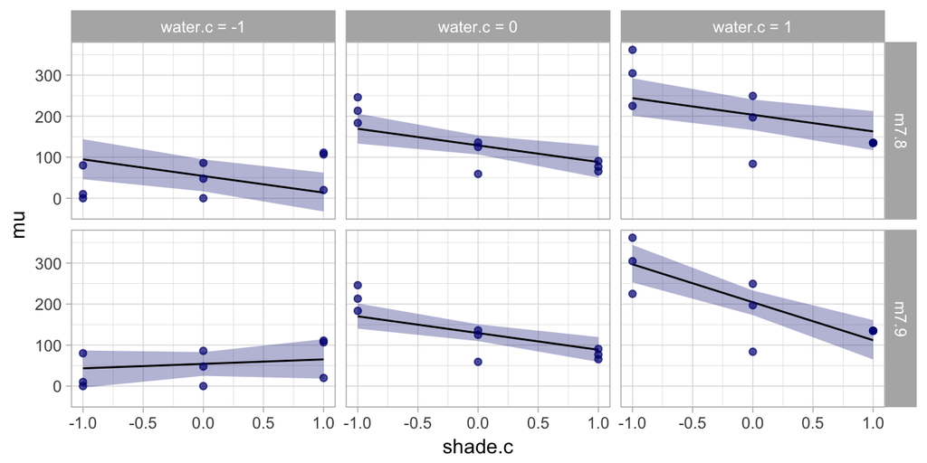

```r
Blooms_predict <-
  expand.grid(shade.c = -1:1, water.c = -1:1)

m7.8.link <- link(m7.8, data = Blooms_predict, refresh = 0)
m7.9.link <- link(m7.9, data = Blooms_predict, refresh = 0)

# We can put two models together above and below or side by side.
# Above/below let's us use facets to compare the model predictions.

Blooms_predict <-
  bind_rows(
    Blooms_predict %>%
      mutate(
        mu = apply(m7.8.link, 2, mean),
        lo = apply(m7.8.link, 2, PI, 0.97)[1,],
        hi = apply(m7.8.link, 2, PI, 0.97)[2,],
        model = "m7.8"
      ),
    Blooms_predict %>%
      mutate(
        mu = apply(m7.9.link, 2, mean),
        lo = apply(m7.9.link, 2, PI, 0.97)[1,],
        hi = apply(m7.9.link, 2, PI, 0.97)[2,],
        model = "m7.9"
      )
  )

gf_ribbon(lo + hi ~ shade.c, data = Blooms_predict, fill = "navy")  %>%
gf_line(mu ~ shade.c, data = Blooms_predict)  %>%
gf_point(blooms ~ shade.c, data = Tulips, alpha = 0.7, color = "navy") %>%
gf_facet_grid(model ~ paste0("water.c = ", water.c))
```

#### R Code 7.29

```r
m7.x <- lm(blooms ~ water + shade + water:shade, data = Tulips)
coef(m7.x)
```

```
## (Intercept)       water       shade water:shade
##  -150.81074   181.50500    64.10056   -52.85167
```

#### R Code 7.30

```r
# short hand notation
m7.x <- lm(blooms ~ water*shade, data = Tulips)
coef(m7.x)
```

```
## (Intercept)       water       shade water:shade
##  -150.81074   181.50500    64.10056   -52.85167
```

#### R Code 7.31

```r
m7.x <- lm(blooms ~ water*shade - shade, data = Tulips)
coef(m7.x)
```

```
## (Intercept)       water water:shade
##   -22.60963   126.56167   -25.38000
```

#### R Code 7.32

```r
m7.x <- lm(blooms ~ water*shade*bed, data = Tulips)
coef(m7.x)
```

```
##      (Intercept)            water            shade             bedb
##      -186.253333       155.971667        86.246667       137.938889
##             bedc      water:shade       water:bedb       water:bedc
##       -31.611111       -50.265000        11.911667        64.688333
##       shade:bedb       shade:bedc water:shade:bedb water:shade:bedc
##       -75.431667         8.993333         8.640000       -16.400000
```

#### R Code 7.33

```r
x <- z <- w <- 1
colnames(model.matrix( ~ x * z * w))
```

```
## [1] "(Intercept)" "x"           "z"           "w"           "x:z"
## [6] "x:w"         "z:w"         "x:z:w"
```

#### R Code 7.34

```r
data(nettle)
Nettle <-
  nettle %>%
  mutate(lang.per.cap = num.lang / k.pop)
head(Nettle, 3)
```

```
##     country num.lang    area k.pop num.stations mean.growing.season
## 1   Algeria       18 2381741 25660          102                6.60
## 2    Angola       42 1246700 10303           50                6.22
## 3 Australia      234 7713364 17336          134                6.00
##   sd.growing.season lang.per.cap
## 1              2.29 0.0007014809
## 2              1.87 0.0040764826
## 3              4.17 0.0134979234
```